# EuroLeague Final Four 2026 — Athens

Team Behavior: Assist Networks, Duo & Trio Clashes

Author

Giannis Tsougkrianis

Published

May 20, 2026

[figure not shown]

## Introduction

Four teams. One city. Athens hosts the EuroLeague Final Four for the first time in its modern era, and the two semifinal matchups could not be more different in character. Olympiacos vs. Fenerbahçe Beko is a battle of historical giants playing contrasting styles on both ends. Valencia Basket vs. Real Madrid is a Spanish derby that doubles as a philosophical clash between a rising collective and the continent’s most decorated club. This analysis cuts through the noise using lineup combination data, assist network topology, and recency-weighted ratings to answer one question: who is actually built for a single-elimination moment?

## Part I — Reading the Networks: How Each Team Moves the Ball

Before duos and trios, we start with the DNA: how does each team distribute its offense through the assist graph? Four metrics frame the picture.

**Entropy** measures how evenly assists are distributed across passers. A score of 1.0 means every player passes equally; 0.0 means one player does everything. **Degree centrality** measures how hub-centric the network is — the higher the number, the more the flow depends on one or two connectors. **Clustering coefficient** captures whether players form tight sub-groups or a more open, chain-like flow. **Mean flux polarization** measures how clearly roles are split between facilitators (net assist givers) and finishers (net assist receivers).

| Team | Entropy | Degree Centrality | Clustering | Flux Polarisation | Communities |
| --- | --- | --- | --- | --- | --- |
| Olympiacos | 0.864 | 0.245 | 0.585 | 11.31 | 2 |
| Fenerbahçe | 0.739 | 0.264 | 0.541 | 11.61 | 3 |
| Valencia Basket | 0.888 | 0.339 | 0.787 | 15.20 | 2 |
| Real Madrid | 0.870 | 0.300 | 0.610 | 13.66 | 2 |

Based off each teams last 15 games, Valencia Basket has the highest assist entropy in the field (0.888) — their ball movement is the most democratized of the four teams. But they also have the highest degree centrality (0.339) and by far the highest clustering coefficient (0.787), meaning their offense flows through well-defined sub-groups that pass tightly within themselves. This is not a contradiction: it describes a team that has multiple self-sufficient offensive pods rather than one star-fed system. Their flux polarization is also the highest (15.20), meaning role separation between creators and finishers is the sharpest in the tournament.

Olympiacos and Real Madrid occupy the middle ground, with entropy scores in the 0.86–0.87 range and degree centrality near 0.25–0.30. Both are well-connected, balanced networks built around clearly defined communities of two.

### SF1 Networks: Olympiacos and Fenerbahçe

#### Olympiacos

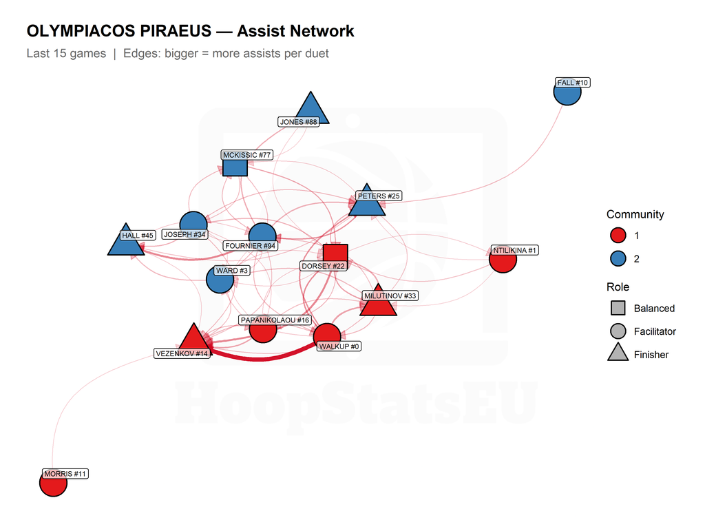

Olympiacos splits neatly into two communities along what appears to be a starting-unit / bench-unit axis. **Community 1** — Dorsey, Milutinov, Morris, Ntilikina, Papanikolaou, Vezenkov, Walkup — reads as the primary starting rotation. **Community 2** — Fall, Fournier, Hall, Jones, Joseph, McKissic, Peters, Ward — is deeper and, as we will see in the duo and trio data, actually carries stronger ratings across several key combinations.

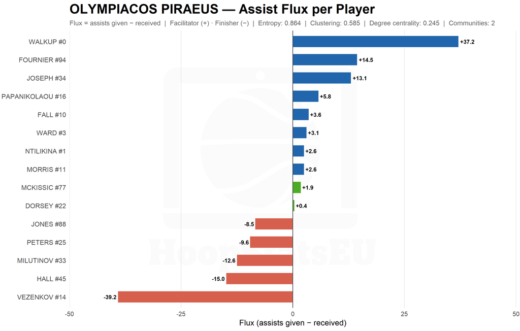

#### Fenerbahçe

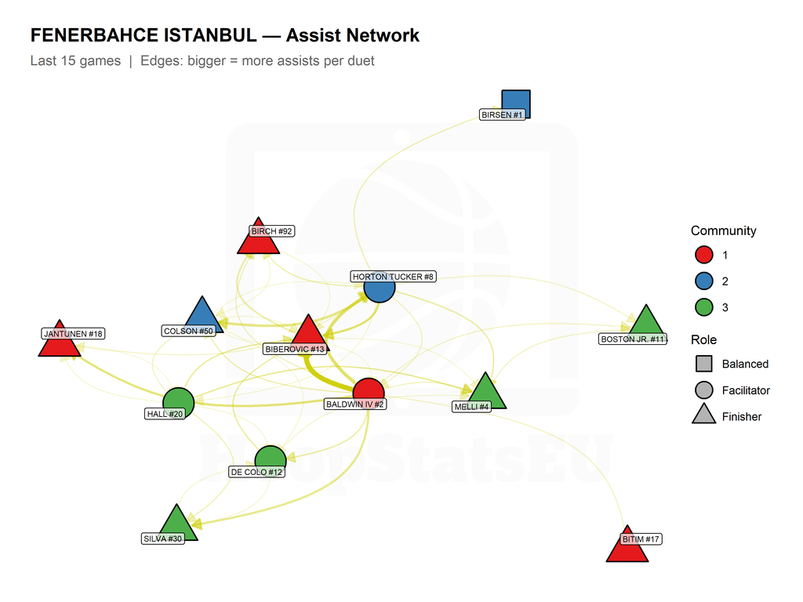

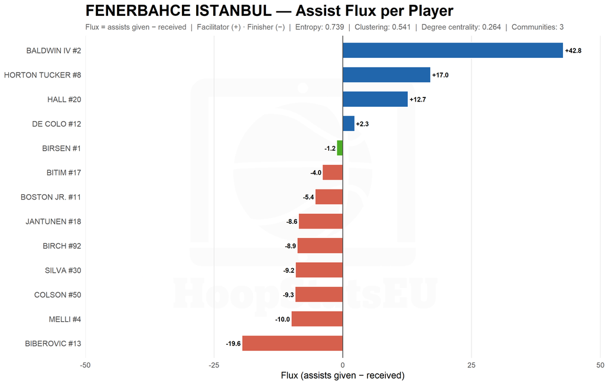

### SF2 Networks: Valencia Basket and Real Madrid

#### Valencia

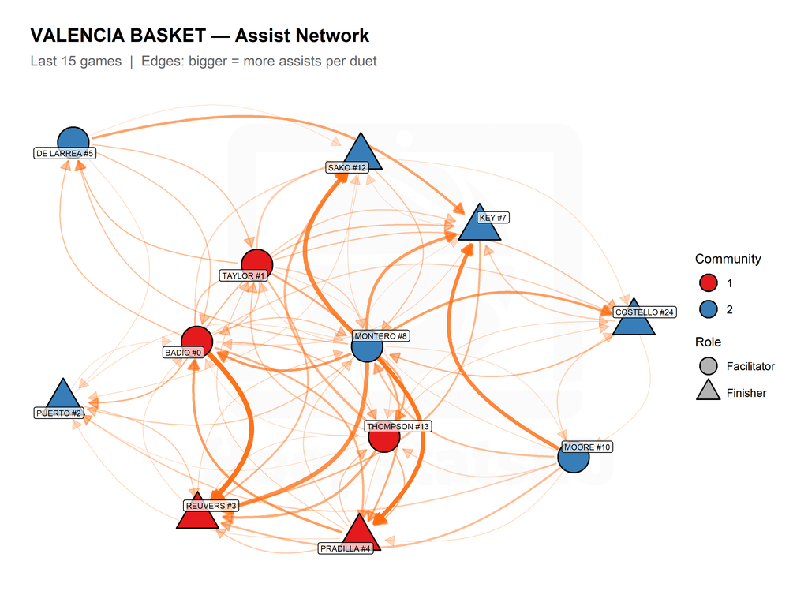

Valencia’s two communities split clearly along player profile lines. **Community 1** — Badio, Pradilla, Reuvers, Taylor, Thompson — tilts younger and more athletic. **Community 2** — Costello, De Larrea, Key, Montero, Moore, Puerto, Sako — is the experience-and-craft group that drives the team’s playmaking. Both communities produce nearly identical season-long net ratings (+11.9 and +12.0), which is a testament to how evenly coach Pedro Martínez has balanced the roster’s offensive load.

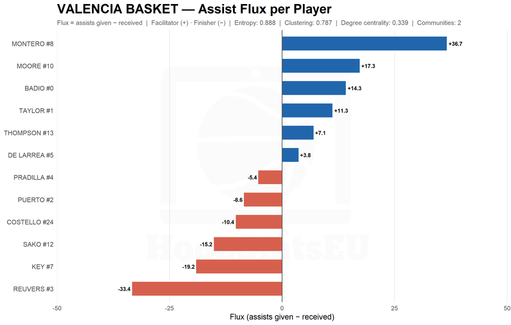

#### Real Madrid

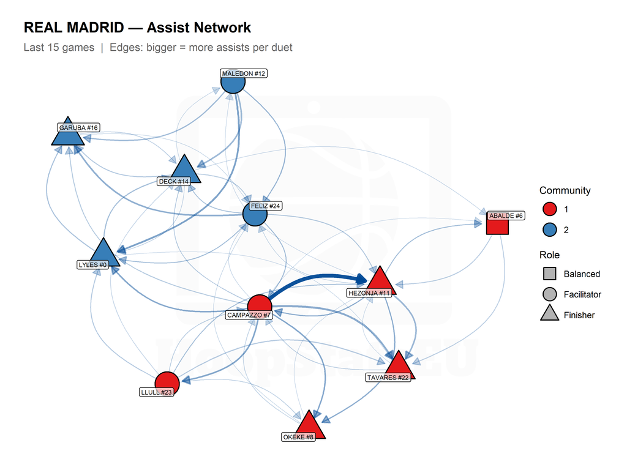

Real Madrid’s two communities are also sharply defined. **Community 1** — Abalde, Campazzo, Hezonja, Llull, Okeke, Tavares — is the star-laden primary unit, the one whose names appear throughout Madrid’s best lineup combinations. **Community 2** — Deck, Feliz, Garuba, Lyles, Maledon — is the complementary rotation, and it is substantially more productive by net rating on a season-long basis (+20.3 vs. +11.7). This inversion — where the backup community outperforms the starter community — is the most interesting structural finding in the Madrid network, and it has direct implications for the Valencia matchup.

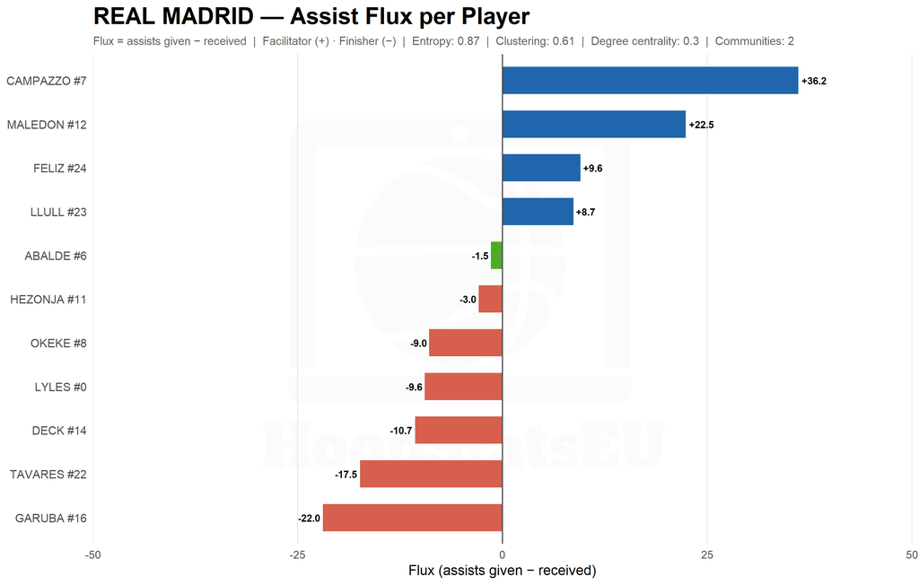

## Part II — Community Performance: Whose Sub-Groups Actually Win?

Networks tell us how the ball moves. Community performance tells us what happens when it arrives.

### Full-Season Community Ratings

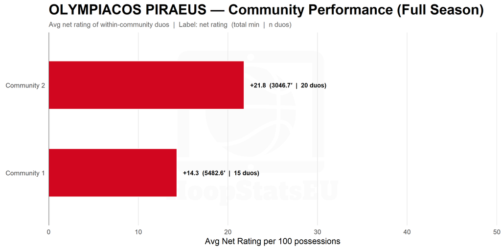

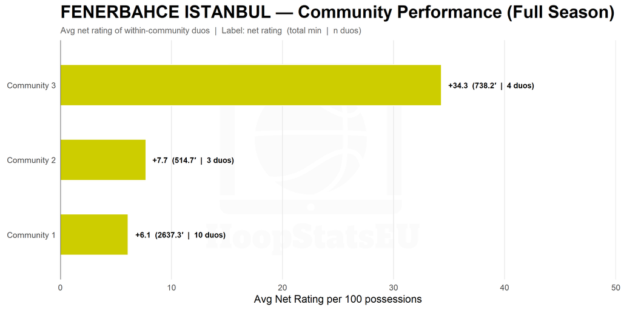

[figure not shown]

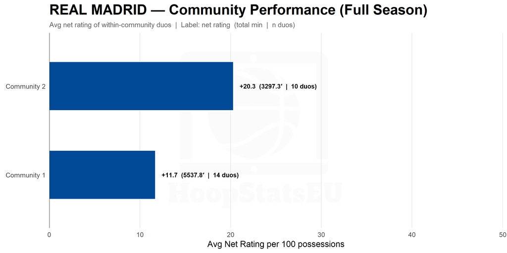

The full-season picture for Olympiacos is clear: Community 2 (+21.8 net, ~3,047 minutes) outperforms Community 1 (+14.3 net, ~5,483 minutes) by over seven points per 100 possessions, with a better defensive rating (106 vs. 112). The “starter” group plays more minutes but generates less value. This is not unusual for a team that rotates heavily, but it does suggest that OLY’s ceiling in a given game depends significantly on how much time the Hall–Ward–Peters–Joseph cluster shares the floor.

For Real Madrid, the gap between their communities is similar in magnitude: Community 2 (+20.3) versus Community 1 (+11.7). Lyles, Garuba, Deck, Feliz, and Maledon — the names behind that +20.3 — are not Madrid’s household names, but the data says they are Madrid’s most productive five-man ecosystem.

### Community Ratings in Head-to-Head Games

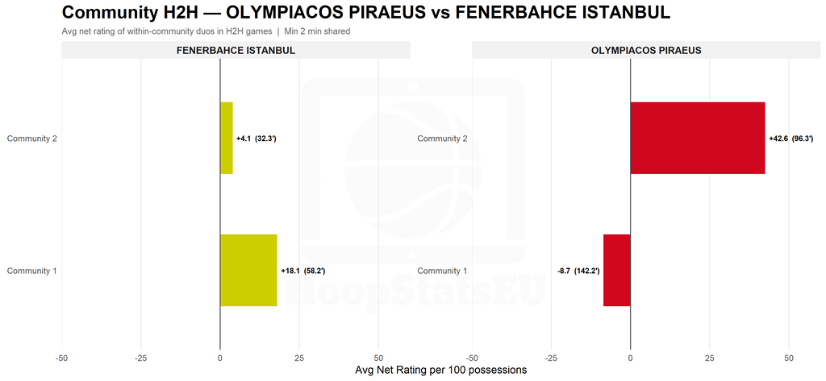

| Team | Community | H2H Net | H2H Off | H2H Def | H2H Min |
| --- | --- | --- | --- | --- | --- |
| Olympiacos | 1 | **–8.7** | 132 | 146 | 142 |
| Olympiacos | 2 | **+42.6** | 140 | 92 | 96 |
| Fenerbahçe | 1 | **+18.1** | 155 | 140 | 58 |
| Fenerbahçe | 2 | **+4.1** | 125 | 120 | 32 |

The numbers above deserve a slow read. Olympiacos Community 1 — the primary starting group — has been outscored in aggregate across H2H games against Fenerbahçe, posting a –8.7 net rating on 142 combined minutes. Their defense in those minutes allowed the equivalent of 146 points per 100 possessions. Meanwhile, Community 2 — Hall, Ward, Peters, Joseph, Fournier, McKissic — posted +42.6 net, 140 offensive rating, and 92 defensive rating. The same team, in the same two games, produced wildly divergent results depending on which community was on the floor.

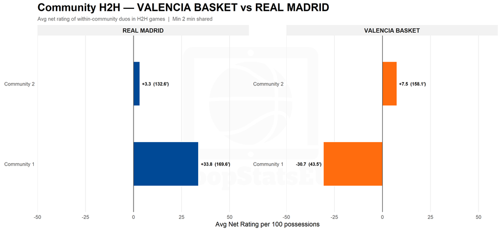

| Team | Community | H2H Net | H2H Off | H2H Def | H2H Min |
| --- | --- | --- | --- | --- | --- |
| Valencia | 1 | **–30.7** | 101 | 122 | 44 |
| Valencia | 2 | **+7.5** | 106 | 119 | 158 |
| Real Madrid | 1 | **+33.8** | 127 | 101 | 170 |
| Real Madrid | 2 | **+3.3** | 126 | 122 | 133 |

These numbers tell a bleak story for Valencia Basket. Community 1 — Badio, Pradilla, Reuvers, Taylor, Thompson — has produced a –30.7 net rating in 44 minutes against Real Madrid. That is not a small-sample aberration at this minute volume; it is a pattern. Community 2 is marginally positive (+7.5) but posted only a 106 offensive rating and a 119 defensive rating — functional but not winning basketball. Real Madrid’s Community 1, meanwhile, posted +33.8 net on 170 minutes. The Campazzo/Llull-anchored unit has dominated these matchups. Community 2 (+3.3) is fine but secondary.

## Part III — Duo and Trio Rankings: The Building Blocks

### Full Season — Top Duos

The full-season duo data reveals the most reliable two-man combinations across the entire EuroLeague campaign. Several findings stand out.

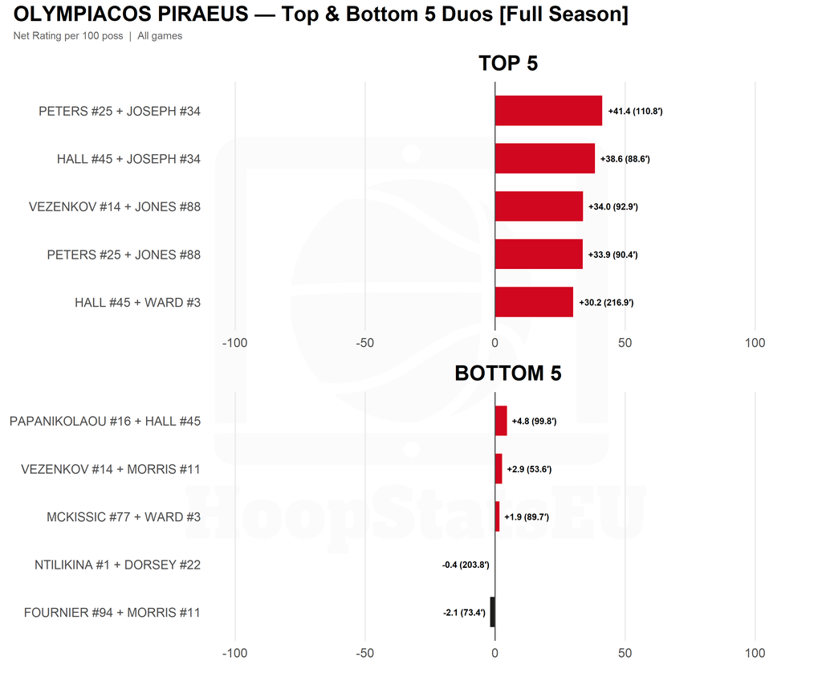

Also, all the team’s duos have been relatively positive in terms of Net Rating, the worst being Evan Fournier + Monte Morris. Morris is part of two out of the five worst duos in Olympiacos season. On the other side, Corry Joseph is part of two of the five best duos in terms of Net Rating. So coach Bartzokas’ decision to trust Joseph instead of Morris as the season progressed, was compeletely justifiable.

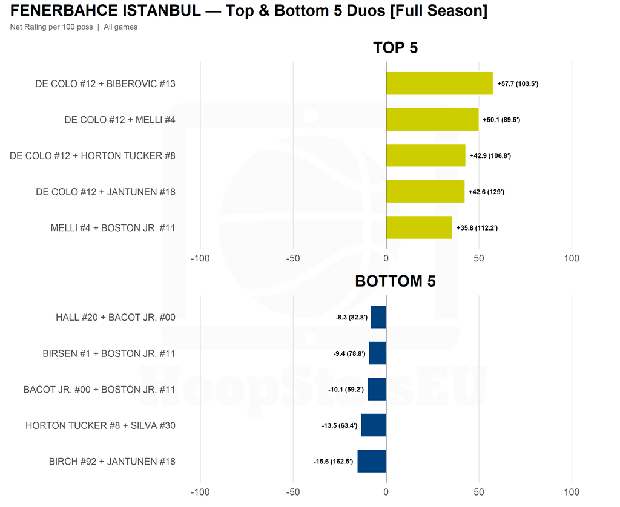

**Fenerbahçe** has four duos above +40 net rating on meaningful minutes: De Colo + Biberovic (+57.7, 104 min), De Colo + Melli (+50.1, 90 min), De Colo + Horton Tucker (+42.9, 107 min), and De Colo + Jantunen (+42.6, 129 min). Nando De Colo - at 38 years of age - has been part of the most dominating duos for Fenerbahçe this season. One of a kind!

One concerning observation: Coach Saras has played Birch and Jantunen together for 163 total minutes—more than any of the top five duos in playing time—yet their net rating is the worst of any duo this season.

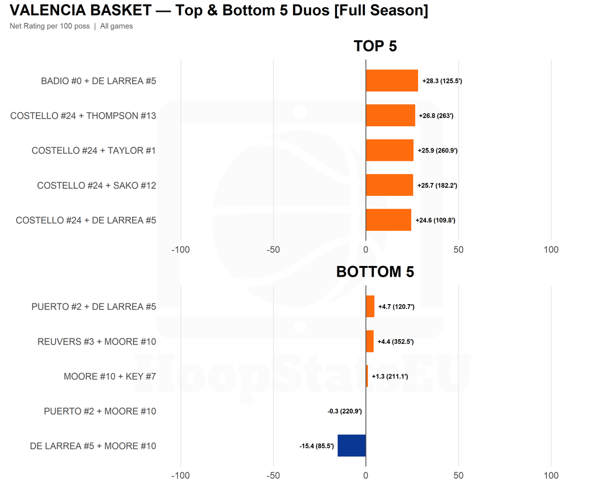

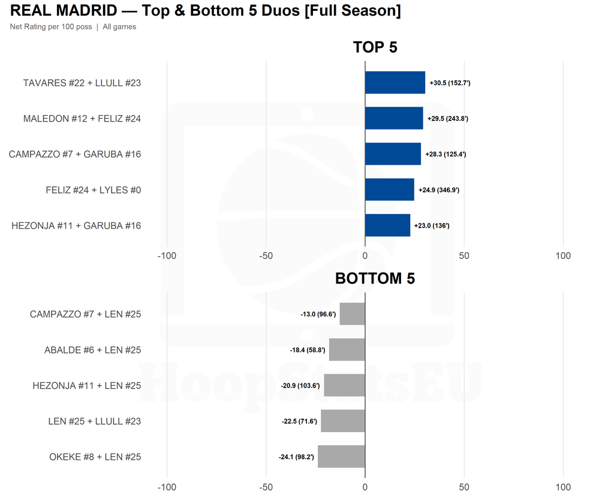

However, coach Scariolo has also made some questionable decisions. Among all Final Four teams, Real Madrid has the worst bottom-five duos, with three pairings playing notable minutes despite posting a Net Rating below –20.

### Full Season — Top Trios

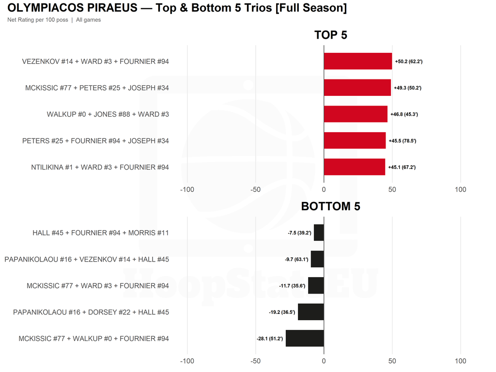

The trio data amplifies what duos hinted at.

**Olympiacos**’ most dominant trio is Vezenkov + Ward + Fournier, outscoring opponents by +50.2 points per 100 possessions across 62 minutes. Close behind is McKissic + Peters + Joseph (+49.3 in 50 minutes), which again underlines that the “Community 2” cluster is what lifts this team’s ceiling. Fournier shows up in three of OLY’s five best three-man units — he’s the perimeter glue that makes so many combinations elite.

That glue cuts both ways, though. Fournier also appears in three of Olympiacos’ bottom-five trios. Two of those pair him with McKissic and either Walkup or Ward — all three are among the most erratic perimeter shooters Olympiacos has, and the spacing craters as a result.

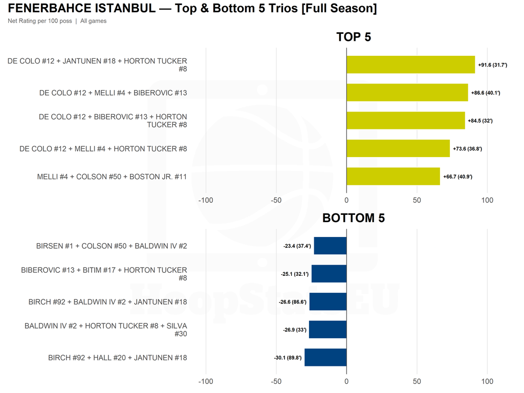

For **Fenerbahçe**, it’s the De Colo + Horton-Tucker tandem that asserts dominance. Three of the club’s five best three-man lineups are built around this duo, each posting a net rating north of +70 in at least 30 minutes of shared court time.

At the other extreme, the Birch + Hall + Jantunen trio has been outscored by 30 points per 100 possessions over 90 minutes — a return that, once again, makes coach Saras’s reliance on that unit a questionable one.

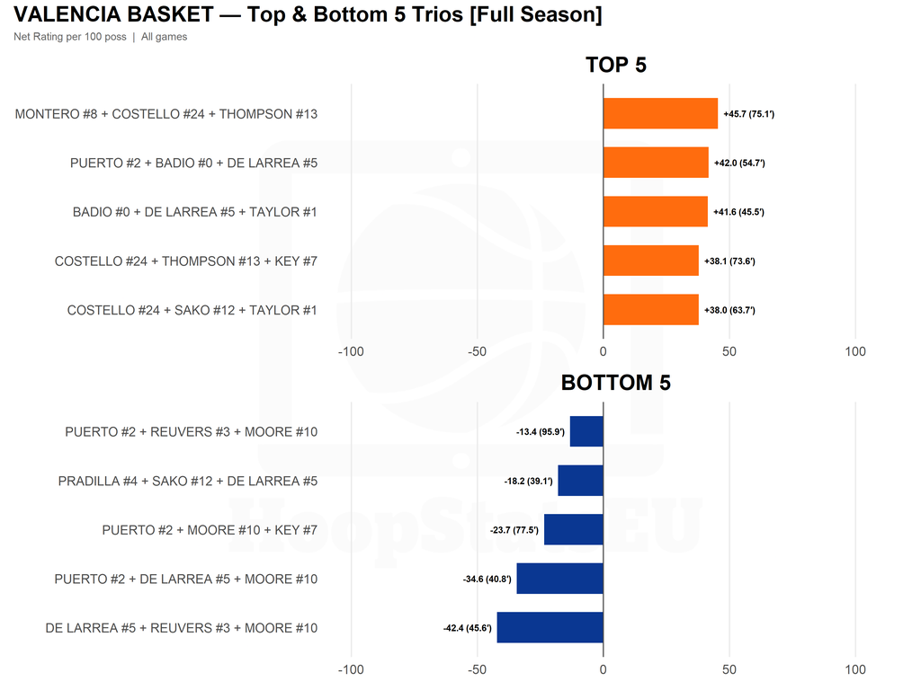

**Valencia**’s trio data paints a picture very similar to what we saw in the two-man units. All five of their best three-man lineups land between +38 and +45.7 net rating, with shared minutes ranging from 46 to 75. Costello features in three of those five — he’s the main big man for the bats.

At the other end, the Moore + De Larrea pair is equally telling. Combinations involving those two account for two of the five worst trios, posting net ratings below –34 in over 40 minutes each.

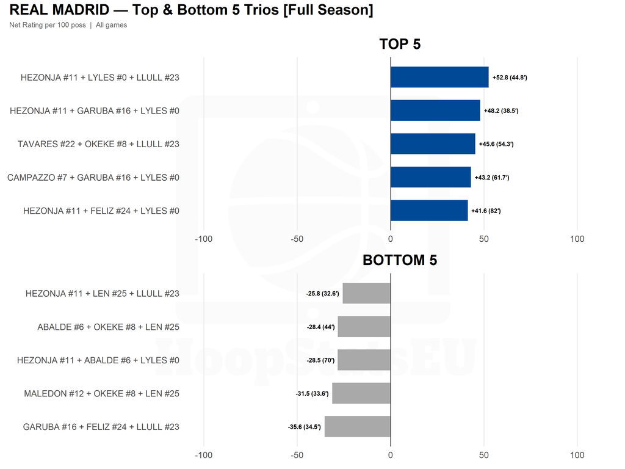

On the opposite end, Alex Len is a fixture in three of the five worst three-man combinations and does not feature in a single top-five unit.

### Recent Form — Top Duos

Zooming into recent form sharpens the picture. Below, we examine duo performance across the last 10 regular-season games and the playoffs.

**Note**: Olympiacos’ playoff series against Monaco was excluded from the recent-form sample. Three of the games were **blowouts**, and Monaco lost key players in Games 2 and 3 — skewing the numbers and making Olympiacos’ recent form look flatteringly better than a true competitive context would suggest.

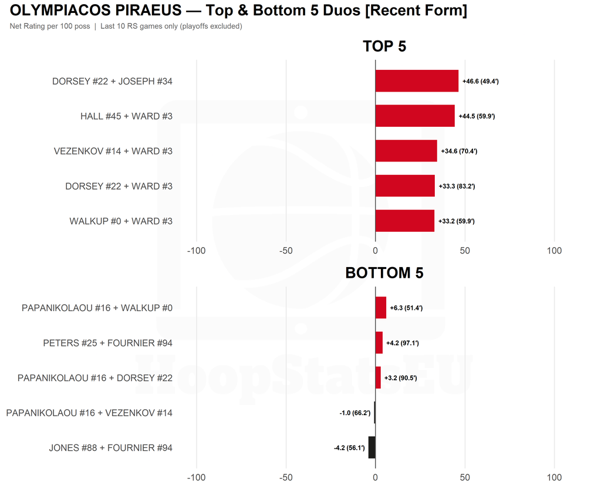

**Olympiacos** show a new name at the top of recent form: Dorsey + Joseph (+46.6, 49 min). Dorsey, a Community 1 member, pairing with Joseph from Community 2 is a cross-community combination that the season-long data did not fully capture. Hall + Ward (+44.5) remains elite. Ward appears in four of the top five recent-form OLY duos — he is the single most important player in their current lineup ecosystem.

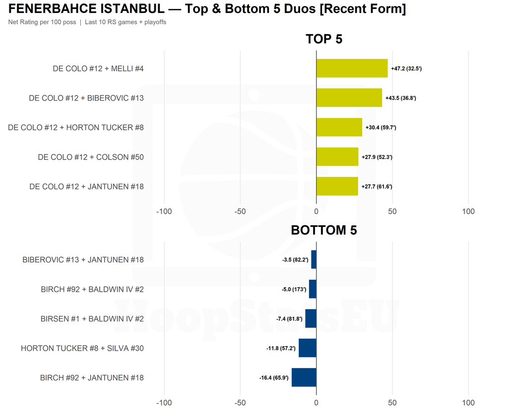

For Fenerbahçe, just one comment is needed: *Nando De Colo is a true legend of the sport*.

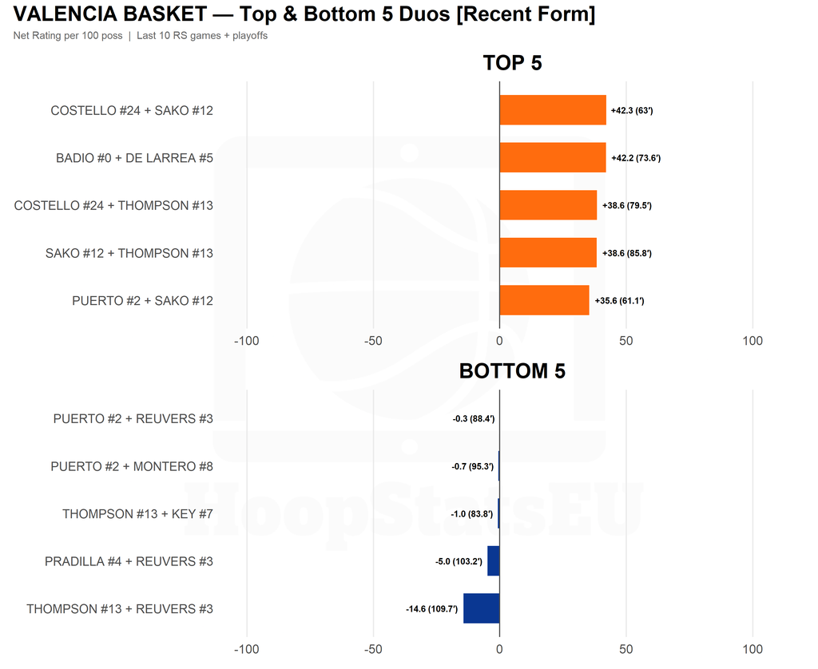

**Valencia**’s most potent duo in recent form is Costello and Sako. The pairing works because Costello can slide seamlessly between the four and the five, unlocking lineup flexibility. Meanwhile, Sako has steadily climbed the hierarchy — he now features in three of the club’s five best two-man units.

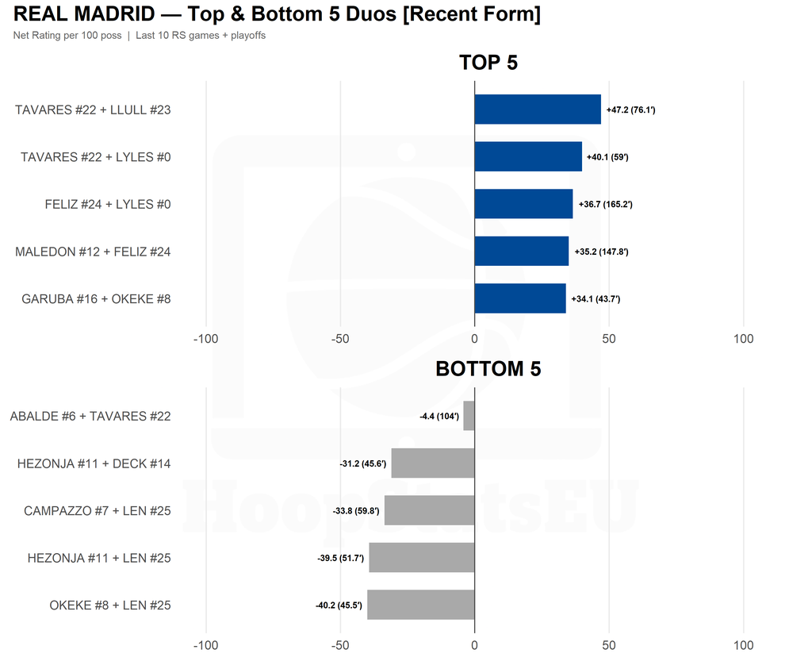

**Real Madrid** have surged in recent form. Tavares and Llull now sit at a +47.2 net rating, a sharp jump from their +30.5 full-season mark. Tavares and Lyles are at +40.1, while Feliz and Lyles (+36.7 over 165 minutes) have become the highest-volume elite duo in the field. The troubling caveat: as of the day of this analysis, Walter Tavares is not expected to be available for the Final Four.

### Recent Form — Top Trios

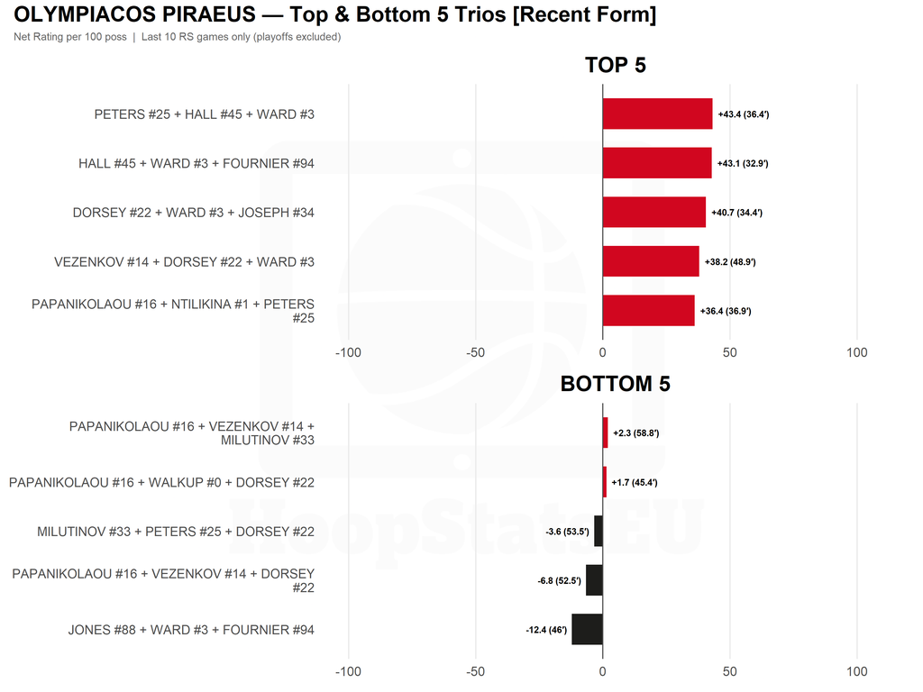

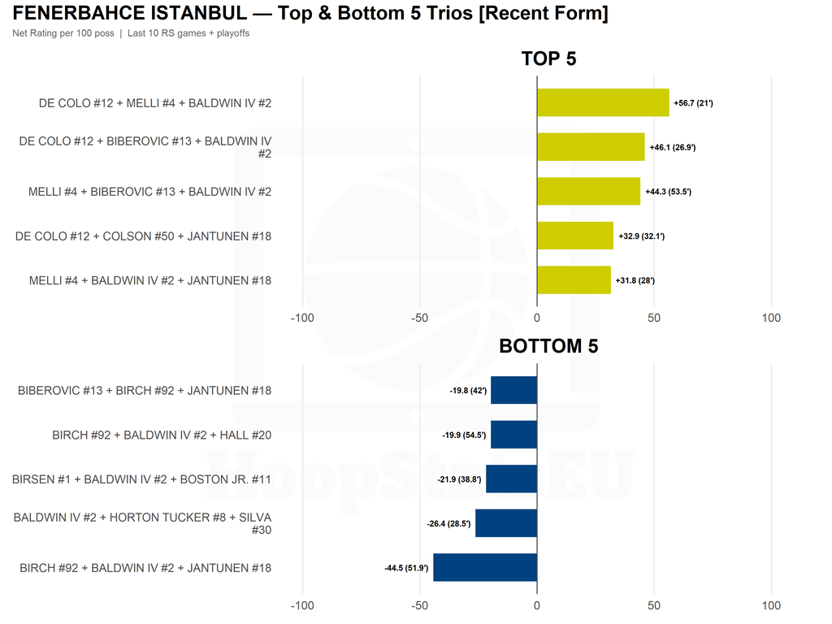

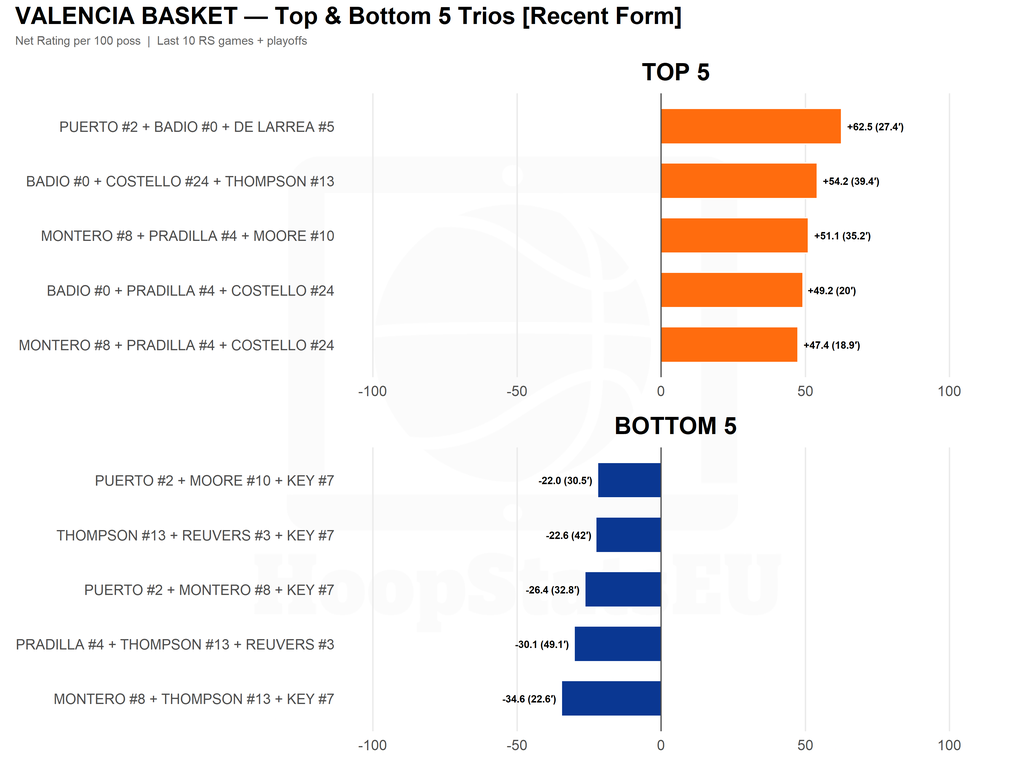

**Valencia**’s best recent trio—Puerto, Badio, and De Larrea—has posted a +62.5 net rating. Badio, in particular, has emerged as the rising star in Valencia’s most effective current trios.

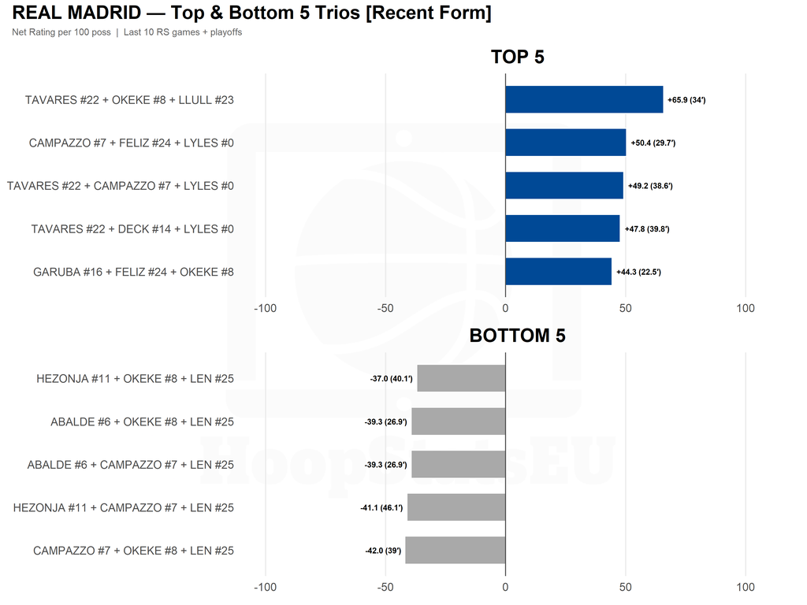

**Real Madrid**’s recent trio numbers are exceptional. The trio of Tavares, Okeke, and Llull leads all three-man lineups with a +65.9 net rating over 34 minutes. Three other Madrid trios also rank above +47, including Campazzo, Feliz, and Lyles at +50.4. With Tavares now sidelined, Real must maximize its use of the *non-Tavares* high-performing trios as much as possible.